# Italy DCP data on COVID-19

Matteo Castagna

08 April, 2020 - 17:54

**[VERY DRAFT]**

An attempt is being made to make sense of the important dataset published daily by the Italian DPC[^1]. It is updated (daily, usually around 17:30 GMT) on GitHub at the following address https://github.com/pcm-dpc/COVID-19.

Data are published both at a County (Provincie) and Region (Regioni) level; the latter offers more information in terms of number of fields. At County level only the “infections” number is given.

Unfortunately an attempt to derive predictions at Regional level delivered faulty results for Regions where the information is not particularly robust. That was driving the predictions at national level off course.

This job is divided in two parts:

1. Figuring out the number of actual infected. It is immediately obvious that the “tested positive” number being supplied is not correct once the death-rate and a reasonable lead time to death since detection are accounted for. Starting from a reasonable hypothesis on the death-rate and that lead time, an actual number of infected can be computed.
2. Predicting the number of deaths for each day/Region over the following two weeks. This is a more challenging and crucial portion of the job: it involves considering methods based on machine learning, optimizing the relevant parameter with cross-validation techniques and then providing a new dataset (forward-looking) and run the optimized model on them. The infected multiplier computed in the first part is used to create the “infected” variable from the reported ones.

Assuming this is done correctly (fairly safe, as the cause of death is provided following the OMS protocol), and given a relatively tight range of the death rate[^2] these are then the numbers guiding the entire work.

While an estimate of the percentage of population actually infected is calculated by applying a very simple model, the number of predicted deaths is obtained via machine learning using the gradient boosting machine algorithm to identify the correct model (GBM)[^3].

GBM seems to offer encouraging results at cross validation level and the predicted path for a selected number of regions is charted at the end[^4].

# 1 The “true” infected percentage of population

## 1.1 Loading data

```r
source("loadDataReg.R")
```

Last observation as of 2020-04-08 17:00:00.

## 1.2 Calculating the infected from the daily number of deceased

```r
dthRateHp <- 0.03
lag <- 14
```

This initial model assumes the most reliable data is provided by the number of deaths at each date/region. Assuming a death-rate of 3% and a lag between the detected infection and the actual death of 14 days, for each date/region, you can derive the actual number of infected people over the total population.

$$\text{Infected*}_{t,R} = \frac {dead_{t+lag,R}}{deathRate}$$

$$\text{Multiplier}_{t,R} = \frac{\text{Infected*}_{t,R}}{\text{Officially Infected}_{t,R}}$$
[R is the index for the Region, *t* is the ID of a specific date]

This can be charted as follows:

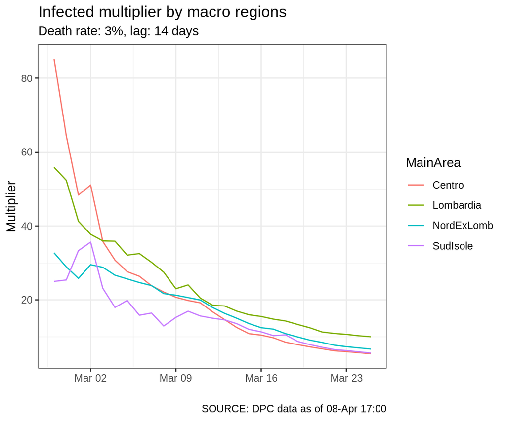

```r
### Multipliers set
MultSet <- dfArea%>%
  arrange(data) %>%
  group_by(MainArea) %>%
  mutate(leadDead = lead(dead, lag),
         hpCasi = leadDead/dthRateHp,
         hpCasiOnCasi = hpCasi/allCases) %>%
  select(data, MainArea, hpCasiOnCasi) %>%
  filter(!is.infinite(hpCasiOnCasi), !is.na(hpCasiOnCasi), !is.nan(hpCasiOnCasi),
         data > as.Date("2020-02-27")) %>%
  ungroup()

### Multipliers chart

MultSet %>%
  ggplot(aes(x= data, y = hpCasiOnCasi, color = MainArea)) +
  geom_line() +
  theme_bw() +
  labs(title = "Infected multiplier by macro regions",
       subtitle = paste0("Death rate: ", format(dthRateHp* 100), "%, lag: ", lag, " days"),
       caption = paste("SOURCE: DPC data as of", format(maxDateTime, "%d-%h %H:%M")),
       x= "",
       y = "Multiplier")
```

A dataset is built and the results projected for the last available date.

The logical jump made is: the Multiplier for (*t,R*) is a good proxy for the multiplier as of (*t+lag,R*). Without that assumption we would be always 14 days behind.

Effectively we assume:

$$\text{Multiplier}_{max(t)} = \frac{\text{Infected*}_{max(t-lag),R}}{\text{Officially Infected}_{max(t),R}}$$

The relevant statistics for each area are provided in the table below (as of the last available date):

| MainArea | Deaths | RepCases | multiplier | CalcCases | CalcPercPop | RepPercPop |
| --- | --- | --- | --- | --- | --- | --- |
| Lombardia | 9722 | 53414 | 10 | 535142 | 5.32 | 0.53 |
| NordExLomb | 5711 | 56938 | 7 | 381055 | 2.15 | 0.32 |
| Centro | 1517 | 18652 | 5 | 101090 | 0.76 | 0.14 |
| SudIsole | 719 | 10418 | 6 | 58543 | 0.30 | 0.05 |

<sup>1</sup> PercPop in percentages

The “multiplier”, based on the number of deaths, for 25-Mar (T-14) is 10.

# 2 Charting the daily deaths path

## 2.1 Tree-based model

This is where machine learning (ie, passing data/outcomes and getting the rules, instead of processing the data/rules to get the outcome) is used.

The model implemented is the Generalized Boosted Regression Model (GBM)

This is a bit of a “black-box” style algorithm which is very useful for prediction[^5] and somewhat useful for inference.

```r
modelSet <- dfArea %>%
  select(data,
         ward,
         ICU,
         homeBound,
         #deltaPositive,
         currentPositives = positive,
         discharged,
         dead,
         repInfected = allCases,
         tests,
         Pop = Census,
         AreaSize = Size,
         AreaAvgDens = Density,
         noCities,
         MainArea) %>%
  left_join(lastMult, by  = "MainArea") %>%
  mutate(MainArea = as.factor(MainArea),
         days = as.numeric(data-min(data)),
         infected = repInfected * hpCasiOnCasi) %>%
  select(-c(data, hpCasiOnCasi)) %>%
  arrange(days) %>%
  group_by(MainArea) %>%
  mutate(DDead = dead-lag(dead)) %>%
  ungroup() %>%
  filter(!is.na(DDead)) %>%
  select(-c(repInfected, dead)) %>%
  as.data.frame()

is.fact <- sapply(modelSet, is.factor)
is.num <- sapply(modelSet, is.numeric)
```

Variables: 1 are factors and 13 are numeric.

```r
dependentVariable <- "DDead"

depVar <- modelSet[, dependentVariable]
num.var <- modelSet[, !(names(modelSet) %in% dependentVariable) & is.num]
fact.var <- modelSet[, is.fact]

correlation <- cor(num.var)

highCorr <- findCorrelation(correlation, cutoff = .80)
highCorrNames <- names(num.var[, highCorr])
```

The objective is to fit the daily change in the deaths number (DDead variable).

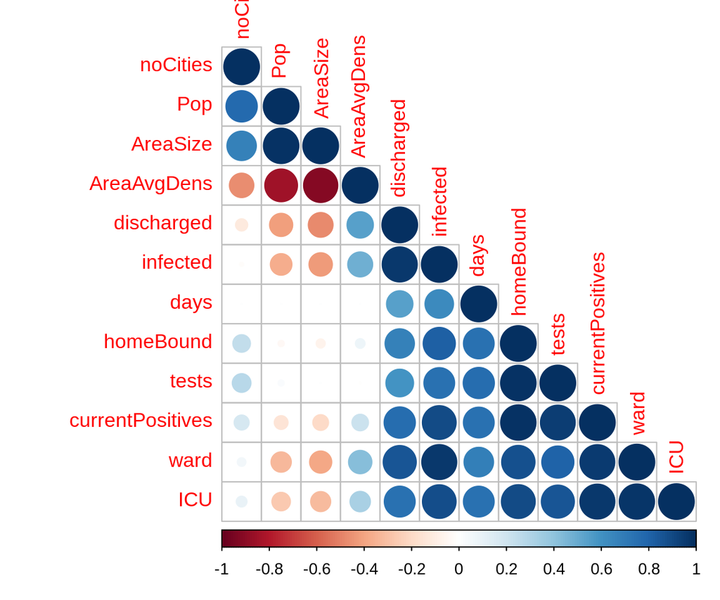

```r
corrplot(correlation, type= "lower", order = "hclust")
```

Highly correlated variables are ward,infected,ICU,currentPositives,tests,AreaSize,AreaAvgDens. Ideally you would get rid of them to avoid multicollinearity. Given it’s tree-based model it doesn’t really matter.

Cross-validation and the optimization of the hyper-parameters of the GBM algorithm has been done separately as it requires substantial run-time.

```r
set.seed(1)
inTraining <- createDataPartition(modelSet[, dependentVariable], p = 0.7, list = FALSE)
train <- modelSet[inTraining,]
test <- modelSet[-inTraining,]

load("optHparsArea.Rda")

gbm.fit.final <- gbm(
  formula = DDead ~ .,
  distribution = "gaussian",
  data = train,
  n.trees = optHpars$optimal_trees,
  interaction.depth = optHpars$interaction.depth,
  shrinkage = optHpars$shrinkage,
  n.minobsinnode = optHpars$n.minobsinnode,
  bag.fraction = optHpars$bag.fraction,
  train.fraction = 1,
  n.cores = NULL,
  verbose = FALSE
)

RMSEtrn <- caret::RMSE(train[, dependentVariable],
                       predict(gbm.fit.final, n.trees = optHpars$optimal_trees))
RMSEtst <- caret::RMSE(test[, dependentVariable],
                       predict(gbm.fit.final, n.trees = optHpars$optimal_trees, test))
```

RMSE train: 59.8 and RMSE test: 76

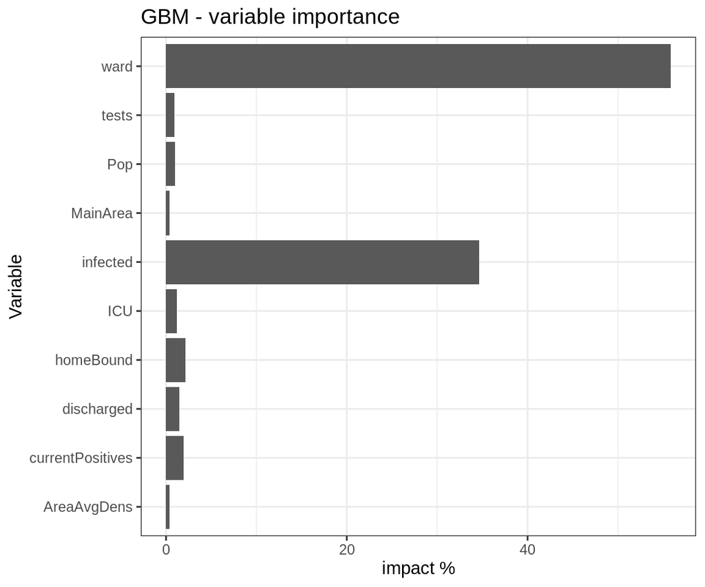

```r
show(chart)
```

Given the nature of the algorithm it is not possible to provide a classical *beta* to the different independent variables. It is possible though charting the partial effect on the dependent variable of the values of a single independent one.

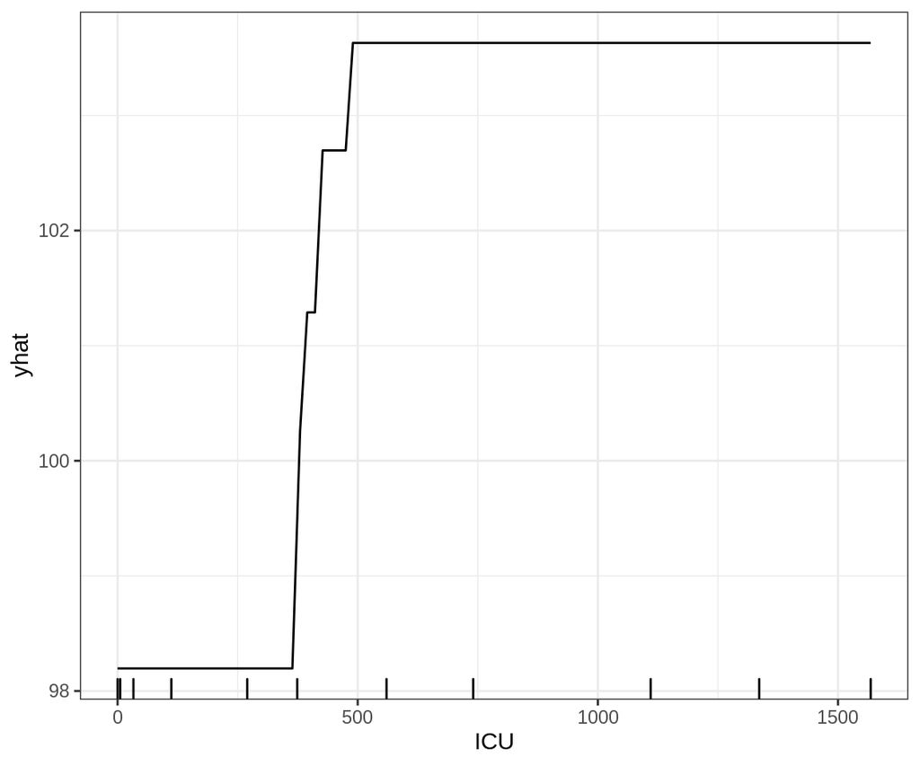

```r
gbm.fit.final %>%
  pdp::partial(pred.var = "ICU", n.trees = optHpars$optimal_trees, grid.resolution = 100) %>%
  autoplot(rug = TRUE, train = modelSet)+
  theme_bw()
```

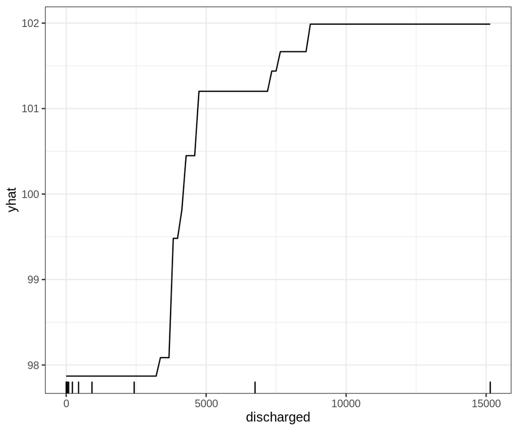

```r
gbm.fit.final %>%
  pdp::partial(pred.var = "discharged", n.trees = optHpars$optimal_trees, grid.resolution = 100) %>%
  autoplot(rug = TRUE, train = modelSet) +
  theme_bw()
```

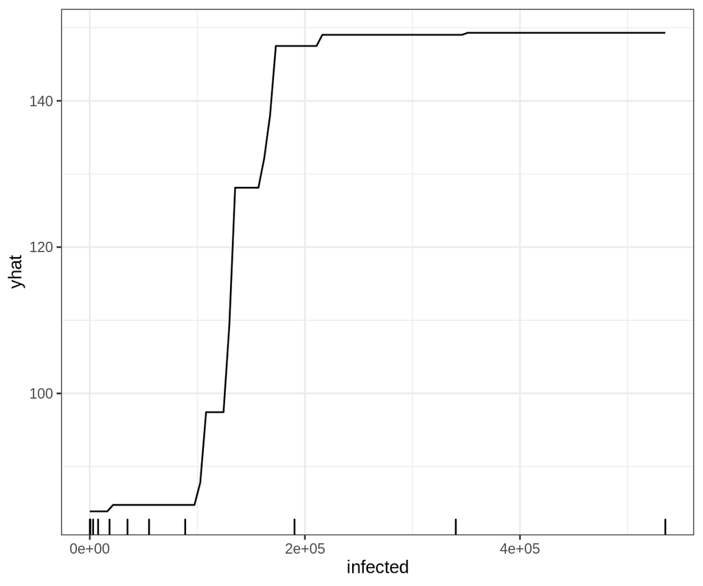

```r
gbm.fit.final %>%
  pdp::partial(pred.var = "infected", n.trees = optHpars$optimal_trees, grid.resolution = 100) %>%
  autoplot(rug = TRUE, train = modelSet) +
  theme_bw()
```

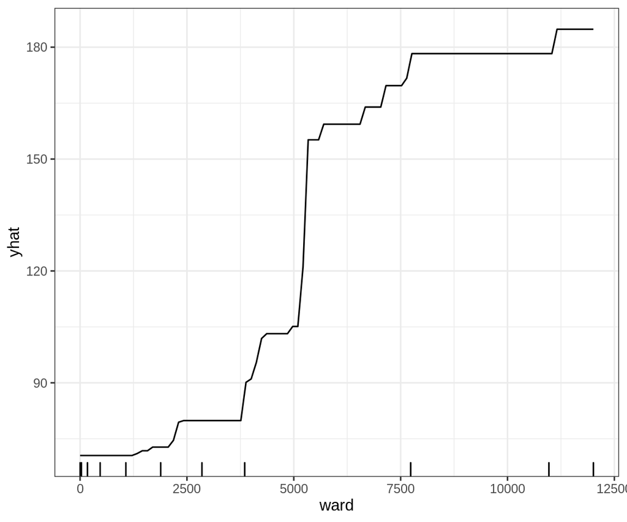

```r
gbm.fit.final %>%
  pdp::partial(pred.var = "ward", n.trees = optHpars$optimal_trees, grid.resolution = 100) %>%
  autoplot(rug = TRUE, train = modelSet) +
  theme_bw()
```

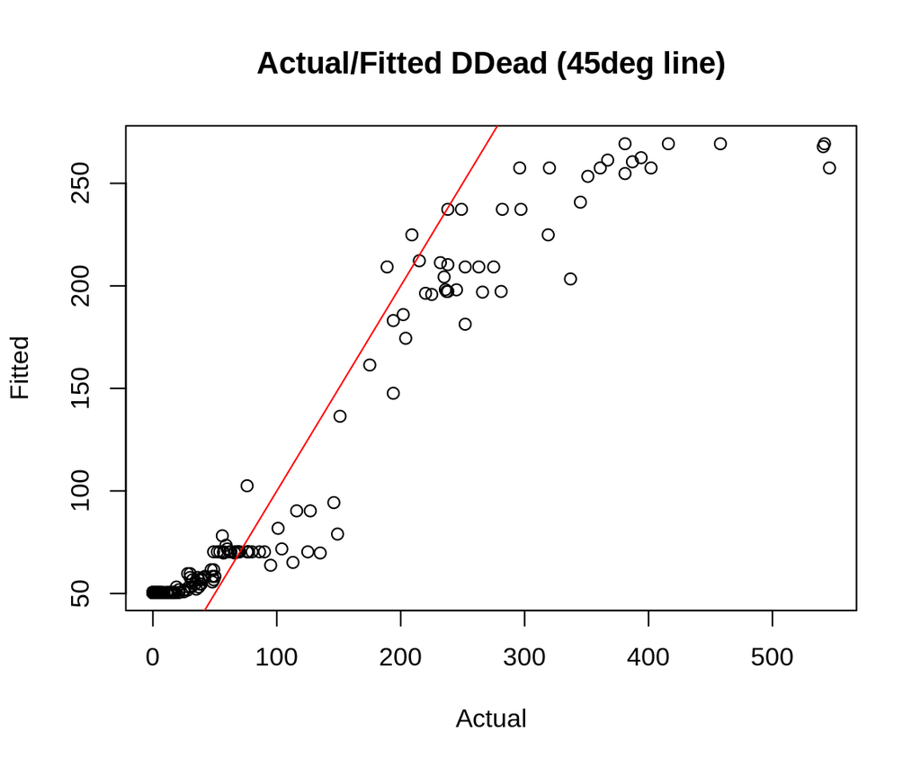

```r
plot(modelSet[, dependentVariable], predict(gbm.fit.final, n.trees = optHpars$optimal_trees),
     main = "Actual/Fitted DDead (45deg line)",
     xlab = "Actual", ylab = "Fitted")
abline(0,1, col = "red")
```

RMSE for the full dataset is 62 dead.

## 2.2 Predicting the deaths path

The output from the GBM model will be used. Two extra weeks will be added assuming the same path currently experienced for the relevant variables.

```r
maxDay = max(modelSet$days)
newDays <- seq(maxDay + 1, maxDay + 15, by = 1)
```

### 2.2.1 Creating the independent variables dataset

The independent variable which need to have forward values are:

- Number of infected in ICU
- Number of infected hospitalized (not in ICU)
- Number of infected (computed as: multiplier times officially-reported)
- Number of infected home-bound
- Number of tests executed
- Number of infected discharged

```r
vars <- modelSet %>%
  select(MainArea, days, ICU, ward, homeBound, discharged, tests, infected,
         currentPositives) %>%
  pivot_longer(cols = c(ICU, ward, homeBound, discharged, tests, infected,
         currentPositives)) %>%
  mutate(value = ifelse(value < 0, 0, value)) %>%
  filter(value != 0) %>%
  mutate(value = log(value)) %>%
  as.data.frame()
```

A quadratic regression on their log values seems a reasonable option. For each region/variable a new set of independent variables is then built.

```r
polyDeg <- 1:2

if(exists("fwdDays")) rm(fwdDays)

for(Reg in unique(vars$MainArea)){
  for(Var in unique(vars$name)) {
    thisBestFit <- data.frame(polyDeg,
                              stat = 0)
    for(deg in thisBestFit$polyDeg) {
      polyModel <- lm(value ~ poly(days, deg),
                      data = vars[vars$MainArea == Reg &
                                    vars$name == Var,])
      thisBestFit$stat[thisBestFit$polyDeg == deg] <- sum(resid(polyModel)^2)/(nrow(polyModel$model)-deg-1)
    }

    thisModel <- lm(value ~ poly(days, thisBestFit$polyDeg[thisBestFit$stat == min(thisBestFit$stat)]),
                    data = vars[vars$MainArea == Reg &
                                  vars$name == Var,])

    thisDf <- data.frame(days = newDays,
                         name = Var,
                         values = exp(predict(thisModel, newdata = data.frame(days = newDays))),
                         MainArea = Reg,
                         AreaAvgDens = areaCensus$Density[areaCensus$MainArea == Reg],
                         Pop = areaCensus$Census[areaCensus$MainArea == Reg],
                         AreaSize = areaCensus$Size[areaCensus$MainArea == Reg],
                         noCities = areaCensus$noCities[areaCensus$MainArea == Reg])

    fwdDays <- if(exists("fwdDays")) rbind(fwdDays, thisDf) else  thisDf
  }
}

rm(Var, Reg, thisDf, thisModel)

fwdDays <- fwdDays %>%
  pivot_wider(names_from = name, values_from = values)
```

[figure not shown]

```r
pastData <- modelSet[, c("days", "DDead", "MainArea")] %>%
  mutate(set = "actual")

newdataPnts <- fwdDays %>%
  mutate(DDead = predict(gbm.fit.final, newdata = fwdDays,
                         n.trees = optHpars$optimal_trees),
         set = "predicted") %>%
  select(days, DDead, MainArea, set)

finalSet <- rbind(pastData, newdataPnts) %>%
  mutate(DDead = ifelse(DDead < 0, 0, DDead))
```

### 2.2.2 Predicting the additional deaths/day/region

Using the new independent variables the forward number of additional deaths for each forward day can be predicted and charted at regional level

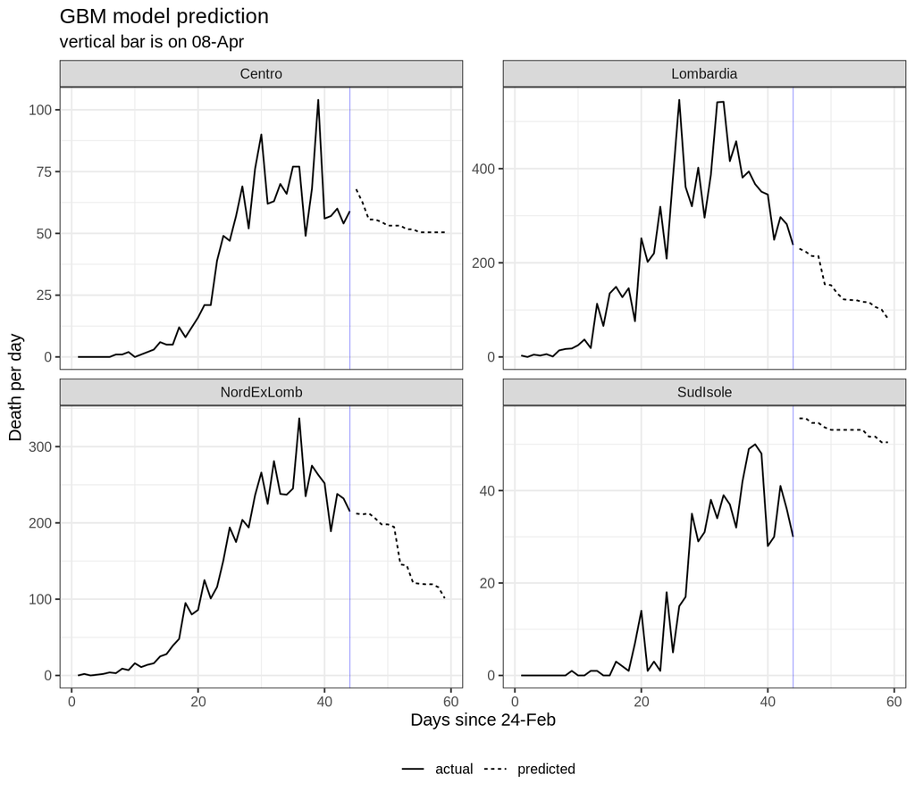

```r
finalSet %>% ggplot(aes(x = days, y = DDead, linetype = set)) +
  geom_line() +
  geom_vline(xintercept =  max(pastData$days), color = "blue", size = 0.1) +
  facet_wrap(~MainArea, scales = "free_y", nrow = 3) +
  theme_bw() +
  scale_linetype_discrete("") +
  theme(legend.position="bottom")+
  labs(title = "GBM model prediction",
       subtitle = paste("vertical bar is on", format(maxDateTime, "%d-%h")),
       x = paste("Days since", format(min(dfArea$data), "%d-%h")),
       y = "Death per day")
```

### 2.2.3 Cumulative charts

Using aras predictions, the path of the daily death count at national level (summing over the different dates the estimates provided before at regional level) can be built.

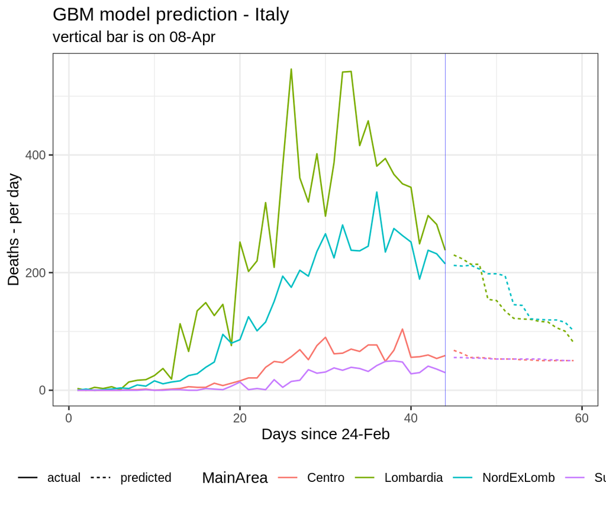

```r
finalSet %>%
  group_by(set, days, MainArea) %>%
  summarise(DDead = sum(DDead)) %>%
  ggplot(aes(x = days, y = DDead, linetype = set, color = MainArea)) +
  geom_line() +
  geom_vline(xintercept =  max(pastData$days), color = "blue", size = 0.1) +
  theme_bw() +
  scale_linetype_discrete("") +
  scale_y_continuous(labels = scales::comma) +
  theme(legend.position="bottom")+
  labs(title = "GBM model prediction - Italy",
       subtitle = paste("vertical bar is on", format(maxDateTime, "%d-%h")),
       x = paste("Days since", format(min(dfArea$data), "%d-%h")),
       y = "Deaths - per day")
```

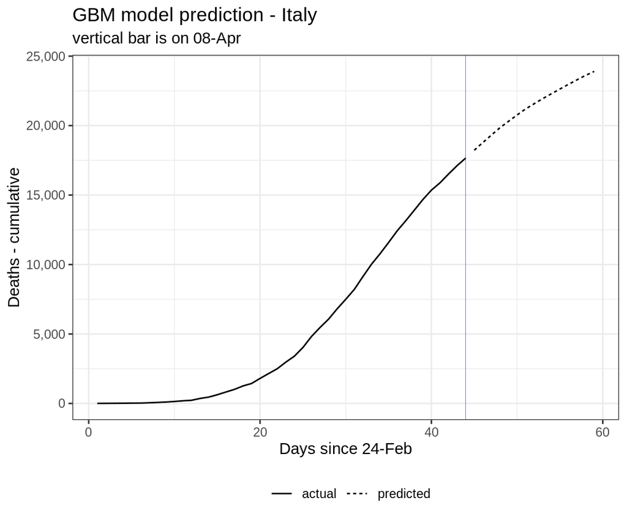

```r
finalSet %>%
  group_by(days) %>%
  summarise(DDead = sum(DDead)) %>%
  mutate(DDeadCum = cumsum(DDead),
         set = ifelse(days >= min(newDays), "predicted", "actual")) %>%
  ggplot(aes(x = days, y = DDeadCum, linetype = set)) +
  geom_line() +
  geom_vline(xintercept =  max(pastData$days), color = "blue", size = 0.1) +
  theme_bw() +
  scale_linetype_discrete("") +
  scale_y_continuous(labels = scales::comma) +
  theme(legend.position="bottom")+
  labs(title = "GBM model prediction - Italy",
       subtitle = paste("vertical bar is on", format(maxDateTime, "%d-%h")),
       x = paste("Days since", format(min(dfArea$data), "%d-%h")),
       y = "Deaths - cumulative")
```

[^1]: Dipartimento della Protezione Civile
[^2]: Anything between 1% and 4%, depending on the age strata.
[^3]: https://projecteuclid.org/download/pdf_1/euclid.aos/1013203451 (J.H.Friedman - 2001)
[^4]: The idea behind this html output is to provide, to the interest readers, the option to have a look at the underlying code used.
[^5]: It has become very popular within the Kaggle community.